# Project: Investigate a Dataset (IMDB)

- Introduction
- Data Wrangling
- Exploratory Data Analysis
- Conclusions

## Introduction

> The dataset that I have chosen is the internet movie database data. Being a movie buff, I didn't have to think twice about choosing a data set. Today I wanna explore the different things about movies which I couldn't while watching a movie, like the taste and poplular genres of people over time, etc.

```python
import  pandas as pd
import numpy as np
import matplotlib.pyplot as plt
```

```python
movies_df = pd.read_csv('tmdb-movies.csv')
```

```python
# printing out the columns.
movies_df.columns
```

```
Index(['id', 'imdb_id', 'popularity', 'budget', 'revenue', 'original_title',
       'cast', 'homepage', 'director', 'tagline', 'keywords', 'overview',
       'runtime', 'genres', 'production_companies', 'release_date',
       'vote_count', 'vote_average', 'release_year', 'budget_adj',
       'revenue_adj'],
      dtype='object')
```

> This dataset clearly has a lot of interesting fields, now let us look into the integrity of the data and pick out the ones we could use.

## Data Wrangling

> The major data part I wanna focus on are the data involving the genre of the movies, the year in which they were released, the budget, the revenue made, runtime, etc. My goal is to compare the trends and results of the movies from the last 30 years to the ones before that.

### General Properties

```python
#printing out the head of the dataframe
movies_df.head()
```

|  | id | imdb_id | popularity | budget | revenue | original_title | cast | homepage | director | tagline | ... | overview | runtime | genres | production_companies | release_date | vote_count | vote_average | release_year | budget_adj | revenue_adj |
| --- | --- | --- | --- | --- | --- | --- | --- | --- | --- | --- | --- | --- | --- | --- | --- | --- | --- | --- | --- | --- | --- |
| 0 | 135397 | tt0369610 | 32.985763 | 150000000 | 1513528810 | Jurassic World | Chris Pratt\|Bryce Dallas Howard\|Irrfan Khan\|Vi... | http://www.jurassicworld.com/ | Colin Trevorrow | The park is open. | ... | Twenty-two years after the events of Jurassic ... | 124 | Action\|Adventure\|Science Fiction\|Thriller | Universal Studios\|Amblin Entertainment\|Legenda... | 6/9/15 | 5562 | 6.5 | 2015 | 1.379999e+08 | 1.392446e+09 |
| 1 | 76341 | tt1392190 | 28.419936 | 150000000 | 378436354 | Mad Max: Fury Road | Tom Hardy\|Charlize Theron\|Hugh Keays-Byrne\|Nic... | http://www.madmaxmovie.com/ | George Miller | What a Lovely Day. | ... | An apocalyptic story set in the furthest reach... | 120 | Action\|Adventure\|Science Fiction\|Thriller | Village Roadshow Pictures\|Kennedy Miller Produ... | 5/13/15 | 6185 | 7.1 | 2015 | 1.379999e+08 | 3.481613e+08 |
| 2 | 262500 | tt2908446 | 13.112507 | 110000000 | 295238201 | Insurgent | Shailene Woodley\|Theo James\|Kate Winslet\|Ansel... | http://www.thedivergentseries.movie/#insurgent | Robert Schwentke | One Choice Can Destroy You | ... | Beatrice Prior must confront her inner demons ... | 119 | Adventure\|Science Fiction\|Thriller | Summit Entertainment\|Mandeville Films\|Red Wago... | 3/18/15 | 2480 | 6.3 | 2015 | 1.012000e+08 | 2.716190e+08 |
| 3 | 140607 | tt2488496 | 11.173104 | 200000000 | 2068178225 | Star Wars: The Force Awakens | Harrison Ford\|Mark Hamill\|Carrie Fisher\|Adam D... | http://www.starwars.com/films/star-wars-episod... | J.J. Abrams | Every generation has a story. | ... | Thirty years after defeating the Galactic Empi... | 136 | Action\|Adventure\|Science Fiction\|Fantasy | Lucasfilm\|Truenorth Productions\|Bad Robot | 12/15/15 | 5292 | 7.5 | 2015 | 1.839999e+08 | 1.902723e+09 |
| 4 | 168259 | tt2820852 | 9.335014 | 190000000 | 1506249360 | Furious 7 | Vin Diesel\|Paul Walker\|Jason Statham\|Michelle ... | http://www.furious7.com/ | James Wan | Vengeance Hits Home | ... | Deckard Shaw seeks revenge against Dominic Tor... | 137 | Action\|Crime\|Thriller | Universal Pictures\|Original Film\|Media Rights ... | 4/1/15 | 2947 | 7.3 | 2015 | 1.747999e+08 | 1.385749e+09 |

5 rows × 21 columns

```python
#checking out the different genres involved in the dataset
genres_set = set()
for genres in movies_df.genres:
    for genre in str(genres).split('|'):
        genres_set.add(genre)
genres_set
```

```
{'Action',
 'Adventure',
 'Animation',
 'Comedy',
 'Crime',
 'Documentary',
 'Drama',
 'Family',
 'Fantasy',
 'Foreign',
 'History',
 'Horror',
 'Music',
 'Mystery',
 'Romance',
 'Science Fiction',
 'TV Movie',
 'Thriller',
 'War',
 'Western',
 'nan'}
```

##### Genres

```python
def remove_nan(genre_series):
    if(genre_series=='nan'):
        return False
    else:
        return True
```

```python
movies_df = movies_df[movies_df.genres.apply(remove_nan)]
```

```python
#checking out the budget and revenue statistics.
movies_df.budget.describe()
```

```
count    1.086600e+04
mean     1.462570e+07
std      3.091321e+07
min      0.000000e+00
25%      0.000000e+00
50%      0.000000e+00
75%      1.500000e+07
max      4.250000e+08
Name: budget, dtype: float64
```

```python
movies_df.revenue.describe()
```

```
count    1.086600e+04
mean     3.982332e+07
std      1.170035e+08
min      0.000000e+00
25%      0.000000e+00
50%      0.000000e+00
75%      2.400000e+07
max      2.781506e+09
Name: revenue, dtype: float64
```

```python
rev_budget_ratio = movies_df.revenue/movies_df.budget
rev_budget_ratio.describe()
```

```
count    6165.000000
mean             inf
std              NaN
min         0.000000
25%         0.138804
50%         1.898151
75%         6.788662
max              inf
dtype: float64
```

```python
movies_df[movies_df.budget<1000].budget.count()
```

```
5755
```

###### Money data

> As it is very clear, we can see that some of the entries are missing for the budget field. However having 0 in the revenue field is acceptable as movies can come at losses too. Assuming this, we however come to another problem. That is, there are some of the movies that was produced just with a budget less that 1000. This however shows error in the data.

###### Another anomaly

> Another anomaly that I observed is that. For some of the budget revenue pair, their ratio was very odd. That is, while describing the ratio, it is observed that the max value for the ratio was very huge. This indicates that either one of the data that was provided is false.

```python
movies_df.runtime.describe()
```

```
count    10866.000000
mean       102.070863
std         31.381405
min          0.000000
25%         90.000000
50%         99.000000
75%        111.000000
max        900.000000
Name: runtime, dtype: float64
```

```python
movies_df[movies_df.runtime<30].describe()
```

|  | id | popularity | budget | revenue | runtime | vote_count | vote_average | release_year | budget_adj | revenue_adj |
| --- | --- | --- | --- | --- | --- | --- | --- | --- | --- | --- |
| count | 231.000000 | 231.000000 | 2.310000e+02 | 2.310000e+02 | 231.000000 | 231.000000 | 231.000000 | 231.000000 | 2.310000e+02 | 2.310000e+02 |
| mean | 116965.943723 | 0.354943 | 3.439301e+05 | 9.090911e+04 | 10.337662 | 49.467532 | 6.636797 | 2005.597403 | 3.932434e+05 | 1.990284e+05 |
| std | 109748.633919 | 0.622270 | 3.976399e+06 | 1.381699e+06 | 8.423998 | 69.096388 | 0.896023 | 11.931609 | 4.206744e+06 | 3.024969e+06 |
| min | 530.000000 | 0.002757 | 0.000000e+00 | 0.000000e+00 | 0.000000 | 10.000000 | 3.300000 | 1963.000000 | 0.000000e+00 | 0.000000e+00 |
| 25% | 26912.500000 | 0.095969 | 0.000000e+00 | 0.000000e+00 | 4.000000 | 14.000000 | 6.050000 | 2004.500000 | 0.000000e+00 | 0.000000e+00 |
| 50% | 73144.000000 | 0.226483 | 0.000000e+00 | 0.000000e+00 | 7.000000 | 24.000000 | 6.700000 | 2010.000000 | 0.000000e+00 | 0.000000e+00 |
| 75% | 200342.500000 | 0.431284 | 0.000000e+00 | 0.000000e+00 | 16.000000 | 49.000000 | 7.300000 | 2013.000000 | 0.000000e+00 | 0.000000e+00 |
| max | 370687.000000 | 8.411577 | 6.000000e+07 | 2.100000e+07 | 29.000000 | 507.000000 | 8.400000 | 2015.000000 | 6.310011e+07 | 4.597555e+07 |

```python
movies_df[movies_df.runtime<30].head()
```

|  | id | imdb_id | popularity | budget | revenue | original_title | cast | homepage | director | tagline | ... | overview | runtime | genres | production_companies | release_date | vote_count | vote_average | release_year | budget_adj | revenue_adj |
| --- | --- | --- | --- | --- | --- | --- | --- | --- | --- | --- | --- | --- | --- | --- | --- | --- | --- | --- | --- | --- | --- |
| 92 | 370687 | tt3608646 | 1.876037 | 0 | 0 | Mythica: The Necromancer | Melanie Stone\|Adam Johnson\|Kevin Sorbo\|Nicola ... | http://www.mythicamovie.com/#!blank/y9ake | A. Todd Smith | NaN | ... | Mallister takes Thane prisoner and forces Mare... | 0 | Fantasy\|Action\|Adventure | Arrowstorm Entertainment\|Camera 40 Productions... | 12/19/15 | 11 | 5.4 | 2015 | 0.0 | 0.0 |
| 100 | 326359 | tt4007502 | 1.724712 | 0 | 0 | Frozen Fever | Kristen Bell\|Idina Menzel\|Jonathan Groff\|Josh ... | NaN | Chris Buck\|Jennifer Lee | NaN | ... | On Anna's birthday, Elsa and Kristoff are dete... | 8 | Adventure\|Animation\|Family | Walt Disney Pictures\|Walt Disney Animation Stu... | 3/9/15 | 475 | 7.0 | 2015 | 0.0 | 0.0 |
| 216 | 286192 | tt3824386 | 0.640151 | 0 | 0 | Lava | Napua Greig\|Kuana Torres Kahele | http://www.pixar.com/short_films/Theatrical-Sh... | James Ford Murphy | NaN | ... | The story follows the love story of two volcan... | 7 | Animation\|Comedy\|Family\|Fantasy\|Music | Pixar Animation Studios | 6/19/15 | 298 | 7.3 | 2015 | 0.0 | 0.0 |
| 279 | 355338 | tt4941804 | 0.442835 | 0 | 0 | Riley's First Date? | Amy Poehler\|Phyllis Smith\|Bill Hader\|Lewis Bla... | NaN | Josh Cooley | NaN | ... | Riley, now 12, is hanging out at home with her... | 5 | Animation\|Family | Walt Disney Pictures\|Pixar Animation Studios | 11/3/15 | 137 | 7.3 | 2015 | 0.0 | 0.0 |
| 334 | 361931 | tt5065822 | 0.357654 | 0 | 0 | Ronaldo | Cristiano Ronaldo | http://www.ronaldothefilm.com | Anthony Wonke | Astonishing. Intimate. Definitive. | ... | Filmed over 14 months with unprecedented acces... | 0 | Documentary | On The Corner Films\|We Came, We Saw, We Conque... | 11/9/15 | 80 | 6.5 | 2015 | 0.0 | 0.0 |

5 rows × 21 columns

###### Runtime

```python
movies_df.popularity.describe()
```

```
count    10866.000000
mean         0.646441
std          1.000185
min          0.000065
25%          0.207583
50%          0.383856
75%          0.713817
max         32.985763
Name: popularity, dtype: float64
```

### Data Cleaning

> The steps taken for clearing some of the problems in the data are described one by one.

###### Inital cleaning

> Stripping off the columns, id, cast, production companies, tagline, website, plot. Because they do not come under the current field of study. And also the fields were null values are present, like for budget, revenue, genres, etc.

```python
# Removing the unwanted columns.
movies_df = movies_df.drop(['id', 'imdb_id',
       'cast', 'homepage','tagline', 'keywords', 'overview',
       'production_companies',
       'budget_adj',
       'revenue_adj'], axis=1)
```

> In our remaining data fields, we want to modify them so that we only take in the necessary fields and drop any unwanted or inaccurate fields. First off, we extract the month from the release date as our analysis only requires that information.

```python
def extract_month(date):
    month = date.split('/')[0]
    return int(month)
```

```python
movies_df['release_month'] = movies_df['release_date'].apply(extract_month)
```

###### Major assumption.

> Since we came across the problem where the budget was not properly entered, that is movies with budget less than 1000 was occured. So only the movies with a budget of over 100,000 is considered for this study.

```python
# Removing the rows where the budget is 0.

movies_df = movies_df[movies_df.budget>100000]
```

##### Another assumption.

> Since the ratio between the revenue and the budget was a bit absurd, I've decided to remove all the rows in which the ratio was above 100. Assuming that a profit of about 100 times is possible.

```python
rev_budget_ratio = movies_df.revenue/movies_df.budget
movies_df = movies_df[rev_budget_ratio<100]
new_rev_budget_ratio = movies_df.revenue/movies_df.budget
new_rev_budget_ratio.describe()
```

```
count    5026.000000
mean        2.994534
std         6.602341
min         0.000000
25%         0.001305
50%         1.229756
75%         3.229909
max        94.076932
dtype: float64
```

##### The result.

> Now we can see that the maximum ratio that occurs in our data is just over 94 times. This does not seem odd. Atleast, compared to the original data that we were looking into.

```python
movies_df.head()
movies_df.to_csv('cleaned_data_final.csv', sep='\t', encoding='utf-8')
#saving the final cleaned up data to a csv file.
```

## Exploratory Data Analysis

> First, we define some functions to plot the data, basically scatter plots, line plots, bar plots and histograms.

```python
def plot_scatter(data_1, data_2, xaxis, yaxis, title):
    plt.scatter(data_1, data_2)
    plt.xlabel(xaxis)
    plt.ylabel(yaxis)
    plt.title(title)
    plt.show()
```

```python
#we define three functions to plot line charts, bar charts and histogram from the dataframe/series.
def plot_series_line(data, yaxis, xaxis, title):
    %matplotlib notebook
    plt.figure(figsize=(1,2))
    data.plot.line()
    plt.xlabel(xaxis)
    plt.ylabel(yaxis)
    plt.title(title)
    plt.grid(True)
```

```python
def plot_series_bar(data, yaxis, xaxis, title):
    %matplotlib notebook
    data.plot.bar()
    plt.xlabel(xaxis)
    plt.ylabel(yaxis)
    plt.title(title)
```

```python
def plot_series_hist(data, yaxis, xaxis, title):
    data.plot.hist(bins=12)
    plt.xlabel(xaxis)
    plt.ylabel(yaxis)
    plt.title(title)
    plt.show()
```

### 1) How does the impact of a movie vary with respect to the time of the year it is released?

> Movies come out at all times of the year. But we look forward to watching movies during the holidays or when we are free. So does that mean that there is a particular time when the movies make the maximum impact? And is it because the movies that come out during this time are particularly very good and attracts people? Let's find out.

```python
#We first group the data by their release month and aggregate the mean.
data = movies_df.groupby('release_month').mean()
```

##### Our first observation.

> For our first observation, plotting the variataion of the mean revenue of the different months were plotted against the respective months. The main objective is to determine if some particular months give higher yield compared to the rest.

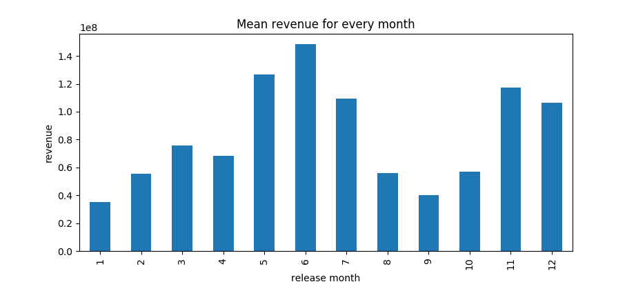

```python
plot_series_bar(data['revenue'], yaxis='revenue', xaxis='release month', title='Mean revenue for every month')
```

##### Holidays sell better

> It is obvious from the given plot that the movies made more revenue during the months of May, June, July, November and December and the average revenue made by movies during the rest of the months are significantly lower. This makes sense because holidays are the best time to watch movies. Moreover, we see the variation of revenue close to the shape of a sine wave. This signifies that the average interest towards movies rises during the holidays and dips during the off holiday time.

##### How do other factors compare?

> Comparing the mean revenue generated per month was one way to compare the variation of the movie impact according to the time of the year. Now, let us compare different other factors that determine the quality of a movie. For instance, let us look into other factors. Like, Do good quality movies( ones with higher vote average ) wait till it is the holiday season to generate better revenue? And so does that mean that it will play a major role in generating more revenue during the season? Let us find out. Also, vote count was also taken in account to compare it with the vote average because movies with higher vote average may not mean that the movie is of better quality. It could mean that only a few votes were recorded and thus cannot be efficiently judged.

```python
normalised_df = pd.DataFrame(index=np.arange(1, 13, 1), columns=['revenue', 'vote_average', 'popularity'])
normalised_df['revenue'] = (data['revenue']-data['revenue'].min())/(data['revenue'].max()-data['revenue'].min())
normalised_df['vote_average'] = (data['vote_average']-data['vote_average'].min())/(data['vote_average'].max()-data['vote_average'].min())
normalised_df['popularity'] = (data['popularity']-data['popularity'].min())/(data['popularity'].max()-data['popularity'].min())
normalised_df['vote_count'] = (data['vote_count']-data['vote_count'].min())/(data['vote_count'].max()-data['vote_count'].min())
```

##### Plotting the data.

> The data considered for this plot are, revenue, popularity and the average vote count. The data were normalised so that they could be compared easier.

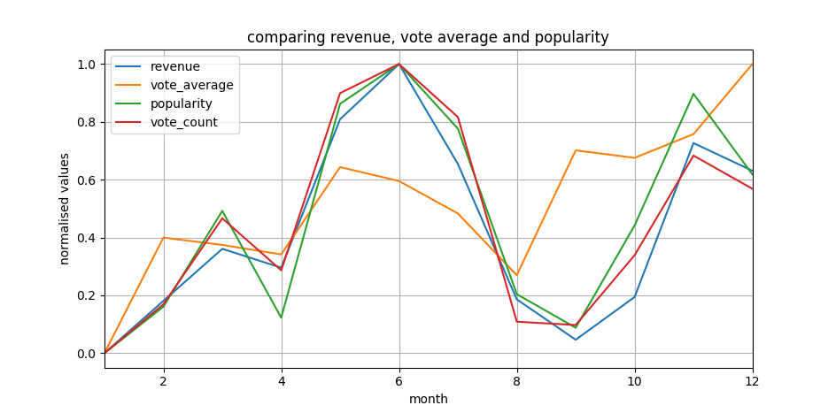

```python
plot_series_line(normalised_df, 'normalised values', 'month', 'comparing revenue, vote average and popularity')
```

##### Better impact than other factors.

> When we compare the variation of factors like the revenue, vote average and populary, it is obvious that the popularity of the movie is inaccordance with the revenue generated by it. That is quite justifiable because popular movies sell better. But the striking result is that, the average popularity of movies is also high during the holiday season, this can be supported by the vote count recieved by the movies during this season. Another striking feature is that these factors(revenue and popularity) are more dependend on the time of the year than the vote average recieved by that movie. This signifies that more than the quality of a movie, the popularity is the major player in determining the success of a movie. And we know that the popularity is high during the mid year.

##### To conclude.

> We can say that above the quality of a movie in general, a major key in determining the success of a movie is the time in which it is released. And this is because the general rise in popularity of movies during the holiday season. This is strongly supported by the fact that movies with higher vote average did not meet the expectations compared to the movies having lower vote averages during the holiday season. The limitation with this assessment is that many of the vote averages were recorded with insufficient number of voters, so that cannot be made an exact measure of comparing it to the other features. However from all the data that we have, it is clear that the movies do sell better during the holiday season.

### 2) How has the movie trends shifted throughout the years?

> We are very lucky to be alive during this time of the universe. We have withnessed the rise of movies from the very primitive animations to advanced CGI and image mapping technologies. Moreover, we are living in a world where everything is accessible to everyone world wide. This has inspired new ideas and experiments which gave us wonderful experiences. So, how was the growth of the movie industry throughout the ages? Let us find out.

> First we group the data by the release year and then we normalize the values so that we can plot them together. The idea is to understand the way these parameters have changed throughout the years.

```python
movies_by_year = movies_df.groupby('release_year').mean()
```

```python
normalized_moviebyyear_df=pd.DataFrame()
```

```python
normalized_moviebyyear_df['vote_average'] = (movies_by_year['vote_average']-movies_by_year['vote_average'].min())/(movies_by_year['vote_average'].max()-movies_by_year['vote_average'].min())
normalized_moviebyyear_df['revenue'] = (movies_by_year['revenue']-movies_by_year['revenue'].min())/(movies_by_year['revenue'].max()-movies_by_year['revenue'].min())
normalized_moviebyyear_df['popularity'] = (movies_by_year['popularity']-movies_by_year['popularity'].min())/(movies_by_year['popularity'].max()-movies_by_year['popularity'].min())
```

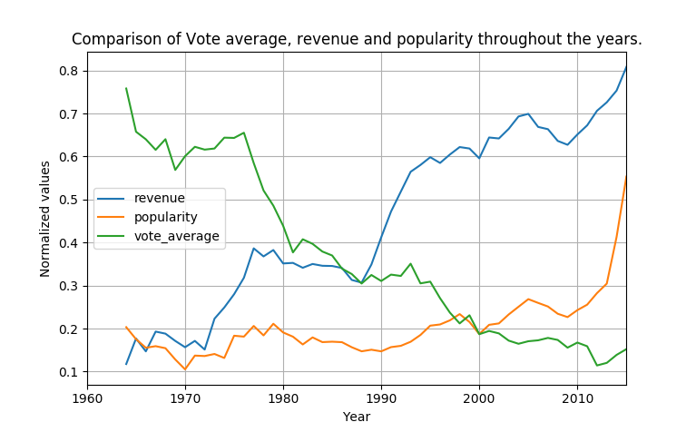

```python
#We now plot these values.
#Rolling mean was selected to understand the curve better.
plot_series_line(normalized_moviebyyear_df[['revenue', 'popularity', 'vote_average']].rolling(window=5).mean(),
                 'Normalized values',
                 'Year',
                 'Comparison of Vote average, revenue and popularity throughout the years.')
```

##### 3 Different trends.

> We can observe here that these three parameters have changed over the years in three different styles. Let us analyse them.

##### 1. Revenue

> > This is fairly obvious that with new movies being released all around the world, the movie industry definately makes a now compared to the previous years. Another major factor is the quantity vs quality of the movies in the dataset throughout the years. Older movies from other countries are not present inside the dataset, which in turn accounts for lower average revenue in the past.

##### 2. Popularity

> > Talking about the popularity, this is proportional to the revenue but this has not increased compared to the revenue.

##### 3. Vote average

> > This is the most striking feature of this data set. This shows the rapid decline of the average vote count of movies. The primary reason for this is because of the fact that, a lot of movies are being released now a days and most of the time the story does not make any sense. Another possibility to this is that, there is a lack of bad movies in the data set which was released before the 90s. Nevertheless, the vote average would have still been on the decline. The rise in popularity and the revenue with the declining vote average signifies over rated movies.

##### Is the movie industry done with giving us good movies?

> Let us now plot the maximum vote averages recieved by a movie to check if we are still able to get good rated movies in the midst of the vast number of movies being released every year.

```python
max_ratings_by_year = movies_df.groupby('release_year').max()['vote_average']
```

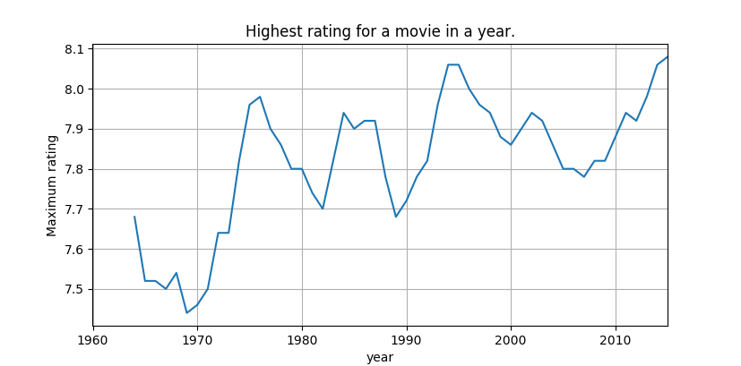

```python
#Here too, the rolling mean was taken.
plot_series_line(max_ratings_by_year.rolling(5).mean(), 'Maximum rating', 'year', 'Highest rating for a movie in a year.')
```

##### Not at all!

> It is very clear from the graph that the movie industry have been giving us very good movies recently. Ofcourse it has its ups and downs but the fact is, Good movies outshine all of them. There is still a fact that some of them get drowned under the others but good movies still make their way to the top.

##### Too many cooks spoil the broth?

> So is it because of the fact that with the number of movies that is being released, The number of bad movies also increases considerably and hence we end up with having the average ratings per year reduced considerably? Let us now plot the average vote per year to the number of movies that were released that year to confirm this.

```python
number_of_movies_by_year = movies_df.groupby('release_year').count()['popularity']
vote_average_by_year = movies_by_year['vote_average']
```

```python
plot_scatter(number_of_movies_by_year, vote_average_by_year,
            'Number of movies',
            'Vote average',
            'Vote average vs the number of movies in that year.')
```

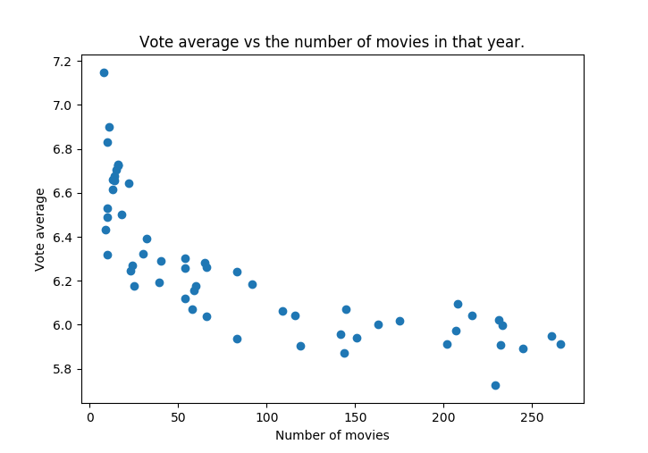

```python
%matplotlib notebook
plt.scatter(number_of_movies_by_year, vote_average_by_year)
plt.xlabel('Number of movies')
plt.ylabel('Vote average')
plt.title('Vote average vs the number of movies in that year.');
```

##### We have the confirmation.

> Two of my suspicions were proved correct with theis plot. The primary one being, too many movies being released has decreased the vote average for that year. This signifies that the overall quality of movies are deteriorating. Now we have analysed that the average rating of older movies were a lot better compared to the present age. But this has two aspects. The number of movies that were released were really low. And there is a possiblity that the bad movies were not recorded in our data set. Thus, we can say that the higher rating of movies for older ones cannot be completely trusted.

## Conclusion

> As we have analysed the data, we can see that the movies released during the holidays have better chances of success. Certainly this will change with the advent of Netflix and other streaming media. But the analysis of that is for another day. However one thing is very much clear, i.e a good movie does not always see success. The popularity it gains during the time which it gets released determines a lot.

> There is an another aspect to this. With the modern ways of advertising, movies often tend to get overrated in the box office, this can lead to false ratings. And this can surprisingly works both ways, an average movie can be rated bad or good. We have seen that movies with moderate popularity before the 90s had considerably good vote average. But over popularity tends to decrease the rating for a movie. However, we can say that this gains revenue for them. The movie industry is in not facing any economic crisis, that's for sure and it won't anytime soon. Talking about the quality, except for some of the movies getting really bad ratings, most of the movies are of good quality.

#### The limitations

> > In this analysis, Some of the data were missing key points. This would have made a lot of differences in our analysis if it was present there. And also, the ratings of movies with very low popularity cannot be trusted as a few people's opinion does not create much impact. A major setback in my analysis however would be the fact that an entire year or an entire month of all the years were summarised. So there might have been months were there were good movies aside from the holiday season, but would've drowned under the huge aggregation. These are the limitations of my analysis.

> So to answer it in a single line.

###### The movie industry is going in a very good direction, technology has made the possibilities endless and so will the filmakers continue to impress us.